# Homework 05

Data Management with SQL

Three problems this week, though they are all related. There are multiple template files for this one, so make sure you download the full zip of all the starting files once you accept below.

[Accept Assignment](https://classroom.github.com/a/96n75lRN)

# Problem 1: Constraining Movies

You’d like to set up some tables to keep track of some movie scores from a variety of reviewers. As such, you have sketched out a basic design shown in the below schematic:

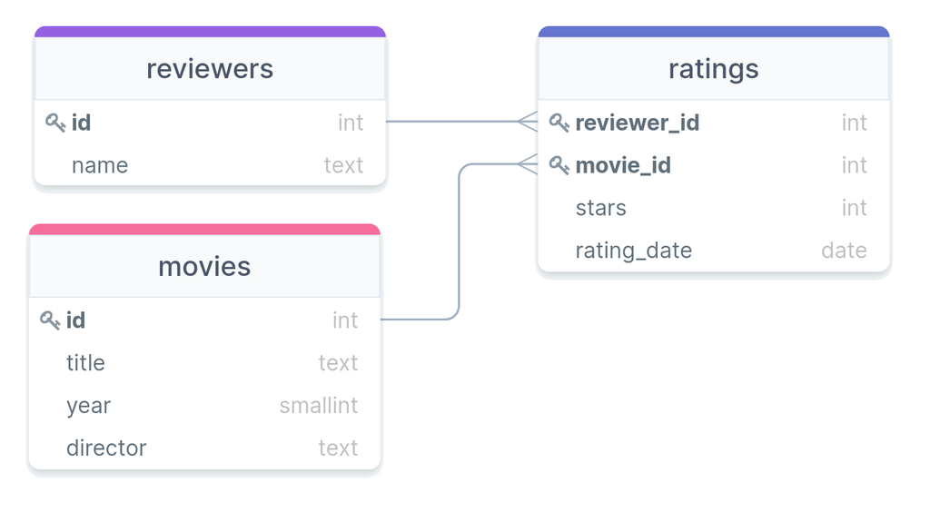

The file in the starting repository named `Prob1.sql` has the initial layout of these tables, in addition to defining a schema to place them into. Using this file as your starting point, you should add the necessary lines to create the correct columns and types for each table, *including primary and foreign keys*. Additionally, there are some further constraints that you would like to place on the data:

1. The combination of `title` and `year` in the `movies` table should be unique. (Only one movie with a given title should come out each year)
2. The `name` of the reviewer should not be null.
3. The number of stars a reviewer gives a movie should not be null.
4. The date that a reviewer rates a movie should not be null.
5. Only movies that came out after the start of the year 1900 are allowed in the `movies` table.
6. Reviewers can only give 1, 2, 3, 4, or 5 stars.
7. All ratings must come after the start of the year 2000.

After adding your columns and constraints, you should be able to execute everything within `Prob1.sql` to create your necessary tables. To test that everything has gone well, you should then be able to run all the commands in `Successful_Inserts.sql`, which should add all the given rows without any errors. If an error occurs here, go back to your tables and determine what may have happened and fix it. Make sure your column names and types are just as indicated in the schematic. Once everything in `Successful_Inserts` is inserting successfully, **upload your `Prob1.sql` back to GitHub to submit this problem.** (Though you may want to wait until the next two problems are complete to ensure you don’t need to make further changes here.)

# Problem 2: Finding Flaws

1. ```
   INSERT INTO hw5.movies (id,title,year,director)
   VALUES
    (2,'The Graduate',1967,'Mike Nichols');
   ```

2. ```
   INSERT INTO hw5.movies (id,title,year,director)
   VALUES
     (51,'The Graduate',1865,'Mike Nichols');
   ```

3. ```
   INSERT INTO hw5.ratings (reviewer_id,movie_id,stars,rating_date)
   VALUES
     (4,36,5,'2010-01-01');
   ```

4. ```
   DROP TABLE hw5.reviewers;
   ```

5. ```
   INSERT INTO hw5.ratings (reviewer_id,movie_id,stars,rating_date)
   VALUES
     (1,3,NULL,'2015-04-02');
   ```

6. ```
   INSERT INTO hw5.ratings (reviewer_id,movie_id,stars,rating_date)
   VALUES
     (1,3,3,'1999-04-18');
   ```

7. ```
   INSERT INTO hw5.reviewers (id,name)
   VALUES
     (11,'Daniel Day');
   ```

# Problem 3: Finding Compound Flaws

1. ```
   INSERT INTO hw5.ratings (reviewer_id,movie_id,stars,rating_date)
   VALUES
     (1,3,6,'1999-04-18');
   ```

2. ```
   INSERT INTO hw5.ratings (reviewer_id,movie_id,stars,rating_date)
   VALUES
     (1,2,0,'2012-02-18');
   ```

3. ```
   DROP TABLE hw5.movies;
   ```

4. ```
   INSERT INTO hw5.ratings (reviewer_id,movie_id,stars,rating_date)
   VALUES
     (4,3,-2,'2014-01-03');
   ```

5. ```
   INSERT INTO hw5.reviewers (id,name)
   VALUES
     (20,NULL);
   ```

6. ```
   INSERT INTO hw5.ratings (reviewer_id,movie_id,stars,rating_date)
   VALUES
     (2,3,4.3,'1989-10-30');
   ```

7. ```
   INSERT INTO hw5.ratings (reviewer_id,movie_id,stars,rating_date)
   VALUES
     (1,3,3,NULL);
   ```

8. ```
   INSERT INTO hw5.movies (id,title,year,director)
   VALUES
     (51,'The Graduate',1867,'Mike Nichols'),
     (52,'The Graduate',1867,'Krzysztof Kieslowski');
   ```

*Sidenote: These ratings were all artificially generated for these mysterious reviewers, so if your favorite movie on the list didn’t get an appropriate score, then I apologize!*